# Customized Pricing v5 analysis

## Initilize R environment

Set language and load relevant packages.

```r
Sys.setenv(LANG = "en")

require("plyr")
require("ggplot2")
```

## Preparing data for analysis

First set the working directory [NOTE: you need to modify the path below to the actual folder having the data file]. Then read the csv data files and have a quick look

```r
#NEED TO FIRST SET R WORKING DIRECTORY TO WHERE THE FILES ARE LOCATED!!!
#setwd("~/PATH/TO/DATA/FILE")

load("../data/data.v5.masked.Training.RData")
load("../data/data.v5.masked.Validation.RData")

head(dataT, n=10)
```

```
      PricingDate     Product      Customer    Channel     Territory ContractQuantity InvoicePrice InvoiceAmount NetPrice NetAmount Discount isDiscount
23398   11-OCT-12 Product_123  Customer_755  Channel_7  Territory_32                1        35.29         35.29    35.29     35.29   0.0000      FALSE
1377    27-DEC-12  Product_88 Customer_1726  Channel_8 Territory_111               20        21.70        434.00    21.70    434.00   0.0000      FALSE
7862    30-OCT-12 Product_104  Customer_739  Channel_4  Territory_11               30        15.00        450.00    15.00    450.00   0.0000      FALSE
7074    22-NOV-12  Product_73  Customer_367  Channel_7   Territory_1               12        18.13        217.56    18.13    217.56   0.0000      FALSE
21667   24-SEP-12  Product_52 Customer_1444 Channel_10  Territory_30               20        40.00        800.00    40.00    800.00   0.0000      FALSE
309     22-OCT-12  Product_91  Customer_767  Channel_8   Territory_6               20        20.00        400.00    20.00    400.00   0.0000      FALSE
13483   02-NOV-12 Product_130 Customer_1707  Channel_7  Territory_97               20       107.00       2140.00   107.00   2140.00   0.0000      FALSE
22501   04-SEP-12  Product_52 Customer_1262  Channel_4  Territory_23               10        40.00        400.00    40.00    400.00   0.0000      FALSE
22247   20-JUL-12  Product_25  Customer_642  Channel_7  Territory_15              150        16.55       2482.50    16.55   2482.50   0.0000      FALSE
8449    03-JUL-12   Product_8  Customer_771  Channel_7  Territory_29               14        13.90        194.60    11.91    166.74   0.1432       TRUE
      nContractQuantity nInvoicePrice
23398          -1.65494       -0.3431
1377            0.36988       -0.7797
7862            0.64393       -1.1112
7074            0.02461       -0.9410
21667           0.36988       -0.2307
309             0.36988       -0.8529
13483           0.36988        0.6527
22501          -0.09862       -0.2307
22247           1.73175       -1.0229
8449            0.12880       -1.1795
```

Visualize the Training data set:

- distribution of *Discount* (taken out those cases with 0 discount)

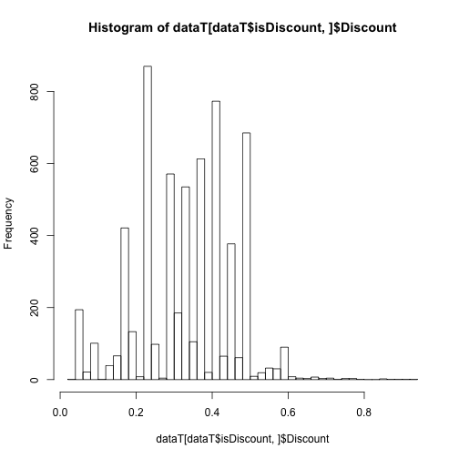

```r
hist(dataT[dataT$isDiscount,]$Discount, breaks=50)
```

- plot *Discount* as a function of *nContractQuantity*, colored by *Channel*

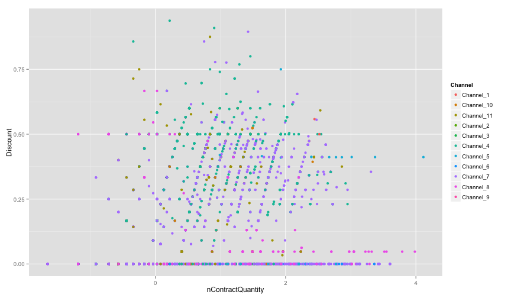

```r
qplot(x=nContractQuantity, y=Discount, colour=Channel, data=dataT)
```

## Analysis Step 1. Classification

To predict whom not to offer any discount. Here we will test multiple classification tools using the **Training** dataset: logistic regression, decision tree, random forest, and SVM, and choose the best.

# 1. logistic regression without using *Territory* variable.

- Setup and train the model

```r
logistic1.model <- glm(isDiscount ~ nContractQuantity + nInvoicePrice + Channel, data=dataT, family=binomial())

summary(logistic1.model)
```

```
Call:
glm(formula = isDiscount ~ nContractQuantity + nInvoicePrice +
    Channel, family = binomial(), data = dataT)

Deviance Residuals:
   Min      1Q  Median      3Q     Max
-3.214  -0.486  -0.200   0.501   3.623

Coefficients:
                   Estimate Std. Error z value Pr(>|z|)
(Intercept)         -0.0814     0.8127   -0.10     0.92
nContractQuantity    1.9692     0.0326   60.38  < 2e-16 ***
nInvoicePrice        0.7394     0.0259   28.52  < 2e-16 ***
ChannelChannel_10   -1.1294     0.8219   -1.37     0.17
ChannelChannel_11   -0.2634     0.8162   -0.32     0.75
ChannelChannel_2   -15.1576  2399.5449   -0.01     0.99
ChannelChannel_3    -7.0863     1.3056   -5.43  5.7e-08 ***
ChannelChannel_4     0.2501     0.8136    0.31     0.76
ChannelChannel_5    -6.2129     0.8818   -7.05  1.8e-12 ***
ChannelChannel_6   -19.7601   140.7232   -0.14     0.89
ChannelChannel_7    -0.7086     0.8133   -0.87     0.38
ChannelChannel_8    -3.7212     0.8164   -4.56  5.2e-06 ***
ChannelChannel_9    15.3863   548.5420    0.03     0.98
---
Signif. codes:  0 '***' 0.001 '**' 0.01 '*' 0.05 '.' 0.1 ' ' 1

(Dispersion parameter for binomial family taken to be 1)

    Null deviance: 23956  on 19001  degrees of freedom
Residual deviance: 13368  on 18989  degrees of freedom
AIC: 13394

Number of Fisher Scoring iterations: 15
```

- Validation using the **Validation** dataset: Predict *True* if the prob > 0.5, then count accuracy using the *table* function.

```r
logistic1.valid <- dataV[c("Channel", "nContractQuantity", "nInvoicePrice", "Discount", "isDiscount")]
logistic1.valid$predP <- predict(logistic1.model, newdata=logistic1.valid, type="response")
logistic1.valid$pred1 <- logistic1.valid$predP>0.5

logistic1.table <- table(logistic1.valid$pred1, logistic1.valid$isDiscount)
logistic1.table
```

```
        FALSE TRUE
  FALSE  4768  806
  TRUE    649 1922
```

# 2. Logistic regression with *Territory* variable.

- Setup and train the model

```r
logistic2.model <- glm(isDiscount ~ nContractQuantity + nInvoicePrice + Channel + Territory, data=dataT, family=binomial())

summary(logistic2.model)
```

```
Call:
glm(formula = isDiscount ~ nContractQuantity + nInvoicePrice +
    Channel + Territory, family = binomial(), data = dataT)

Deviance Residuals:
   Min      1Q  Median      3Q     Max
-3.416  -0.381  -0.082   0.362   4.224

Coefficients:
                        Estimate Std. Error z value Pr(>|z|)
(Intercept)             1.05e-01   1.02e+00    0.10   0.9182
nContractQuantity       2.31e+00   4.12e-02   56.00  < 2e-16 ***
nInvoicePrice           9.00e-01   3.30e-02   27.32  < 2e-16 ***
ChannelChannel_10       1.03e+00   1.12e+00    0.92   0.3573
ChannelChannel_11      -6.90e-01   9.98e-01   -0.69   0.4893
ChannelChannel_2       -1.02e+01   6.52e+03    0.00   0.9987
ChannelChannel_3       -8.06e+00   1.44e+00   -5.61  2.0e-08 ***
ChannelChannel_4       -4.37e-03   9.93e-01    0.00   0.9965
ChannelChannel_5       -4.96e+00   1.21e+00   -4.11  3.9e-05 ***
ChannelChannel_6       -3.27e+01   6.73e+02   -0.05   0.9612
ChannelChannel_7       -8.31e-02   1.00e+00   -0.08   0.9338
ChannelChannel_8       -1.85e+00   1.14e+00   -1.63   0.1034
ChannelChannel_9        1.67e+01   1.46e+03    0.01   0.9908
TerritoryTerritory_10   5.48e-01   3.27e-01    1.68   0.0932 .
TerritoryTerritory_100 -2.03e+01   1.59e+03   -0.01   0.9898
TerritoryTerritory_101 -1.77e+01   4.11e+03    0.00   0.9966
TerritoryTerritory_102 -1.87e+01   2.12e+03   -0.01   0.9930
TerritoryTerritory_103 -3.20e-01   3.40e-01   -0.94   0.3453
TerritoryTerritory_104 -1.97e+01   2.60e+03   -0.01   0.9940
TerritoryTerritory_105 -1.94e+01   8.71e+02   -0.02   0.9822
TerritoryTerritory_106  8.72e+00   3.95e+03    0.00   0.9982
TerritoryTerritory_107 -1.78e+01   7.72e+02   -0.02   0.9816
TerritoryTerritory_108 -1.95e+00   4.80e-01   -4.07  4.7e-05 ***
TerritoryTerritory_109 -2.04e+01   1.62e+03   -0.01   0.9900
TerritoryTerritory_11  -1.65e-01   3.38e-01   -0.49   0.6261
TerritoryTerritory_110  7.23e-01   7.42e-01    0.97   0.3301
TerritoryTerritory_111 -5.20e+00   6.65e-01   -7.81  5.7e-15 ***
TerritoryTerritory_112 -1.32e+00   5.67e-01   -2.33   0.0199 *
TerritoryTerritory_113 -1.06e+00   7.44e-01   -1.43   0.1527
TerritoryTerritory_12  -1.35e+00   6.60e-01   -2.05   0.0407 *
```

[output cut: 90 more lines]

```
TerritoryTerritory_95   1.13e+01   4.92e+02    0.02   0.9816
TerritoryTerritory_96  -1.81e+01   3.13e+03   -0.01   0.9954
TerritoryTerritory_97   1.73e-01   2.88e-01    0.60   0.5478
TerritoryTerritory_98  -1.74e+01   7.97e+02   -0.02   0.9826
TerritoryTerritory_99  -1.62e+00   8.44e-01   -1.92   0.0544 .
---
Signif. codes:  0 '***' 0.001 '**' 0.01 '*' 0.05 '.' 0.1 ' ' 1

(Dispersion parameter for binomial family taken to be 1)

    Null deviance: 23956  on 19001  degrees of freedom
Residual deviance: 10956  on 18877  degrees of freedom
AIC: 11206

Number of Fisher Scoring iterations: 17
```

- Validation using the **Validation** dataset: Predict *True* if the prob > 0.5, then count accuracy using the *table* function.

```r
logistic2.valid <- dataV[c("Channel", "Territory", "nContractQuantity", "nInvoicePrice", "Discount", "isDiscount")]
logistic2.valid$predP <- predict(logistic2.model, newdata=logistic2.valid, type="response")
logistic2.valid$pred1 <- logistic2.valid$predP>0.5

logistic2.table <- table(logistic2.valid$pred1, logistic2.valid$isDiscount)
logistic2.table
```

```
        FALSE TRUE
  FALSE  4876  501
  TRUE    541 2227
```

- Plot the ROC and accuracy curves.

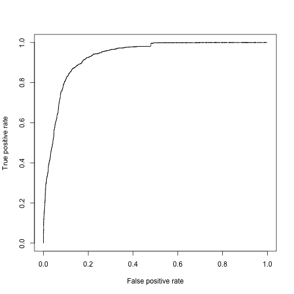

```r
require(ROCR)
logistic2.pred <- prediction(logistic2.valid$predP, logistic2.valid$isDiscount)
# Plot ROC curve
logistic2.ROC <- performance(logistic2.pred, measure = "tpr", x.measure = "fpr")
plot(logistic2.ROC)
```

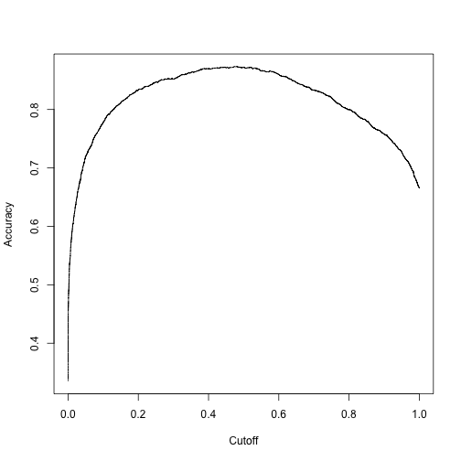

```r
# Plot precision/recall curve
#logistic2.precision <- performance(logistic2.pred, measure = "prec", x.measure = "rec")
#plot(logistic2.precision)
# Plot accuracy as function of threshold
logistic2.accuracy <- performance(logistic2.pred, measure = "acc")
plot(logistic2.accuracy)
```

# 3. Decision tree using the *rpart* package.

- Setup and train the model, then print summary.

```r
require("rpart")
tree2.model <- rpart(as.factor(isDiscount) ~ nContractQuantity + nInvoicePrice + Channel + Territory, data=dataT)
summary(tree2.model)
```

```
Call:
rpart(formula = as.factor(isDiscount) ~ nContractQuantity + nInvoicePrice +
    Channel + Territory, data = dataT)
  n= 19002

      CP nsplit rel error xerror     xstd
1 0.3284      0    1.0000 1.0000 0.010462
2 0.0137      2    0.3431 0.3438 0.007035
3 0.0100      8    0.2337 0.2368 0.005952

Variable importance
nContractQuantity         Territory           Channel     nInvoicePrice
               31                31                20                19

Node number 1: 19002 observations,    complexity param=0.3284
  predicted class=FALSE  expected loss=0.3247  P(node) =1
    class counts: 12832  6170
   probabilities: 0.675 0.325
  left son=2 (9275 obs) right son=3 (9727 obs)
  Primary splits:
      nContractQuantity < -0.06641  to the left,  improve=2781.0, (0 missing)
      Territory         splits as  LRLLLRLLLLLLRRLRLLLRLRRLLLLRRRLRRRRLRRRLRRRLRRRLRLLLLLLLLRLLLRRRLLLLLLLLLRLLLRRLLLRRLLRLLRRRLLRLLLLLRLLLRRLLLLRLL, improve=2033.0, (0 missing)
      Channel           splits as  RLRLLRLLLLR, improve=1233.0, (0 missing)
      nInvoicePrice     < 0.9469    to the right, improve= 293.6, (0 missing)
  Surrogate splits:
      Territory     splits as  LRLLLRLLRRRRRLRRLLRRLRRLLLLRRRLRRRRLRRRLLRRRRLRLRLLRRLLLLRLLLRRRRRLLLLRLLRRLLRLLLRRRLRRLLRRRRLRLRLRLRLLLRRLLRLRLL, agree=0.662, adj=0.307, (0 split)
      Channel       splits as  RRRRRRRRLLR, agree=0.612, adj=0.204, (0 split)
      nInvoicePrice < 0.6726    to the right, agree=0.608, adj=0.198, (0 split)

Node number 2: 9275 observations
  predicted class=FALSE  expected loss=0.04765  P(node) =0.4881
    class counts:  8833   442
   probabilities: 0.952 0.048

Node number 3: 9727 observations,    complexity param=0.3284
  predicted class=TRUE   expected loss=0.4111  P(node) =0.5119
    class counts:  3999  5728
   probabilities: 0.411 0.589
  left son=6 (3132 obs) right son=7 (6595 obs)
  Primary splits:
```

[output cut: 115 more lines]

```

Node number 119: 1463 observations
  predicted class=TRUE   expected loss=0.1012  P(node) =0.07699
    class counts:   148  1315
   probabilities: 0.101 0.899

Node number 236: 416 observations
  predicted class=FALSE  expected loss=0.2115  P(node) =0.02189
    class counts:   328    88
   probabilities: 0.788 0.212

Node number 237: 1063 observations
  predicted class=TRUE   expected loss=0.1176  P(node) =0.05594
    class counts:   125   938
   probabilities: 0.118 0.882
```

```r
printcp(tree2.model)
```

```
Classification tree:
rpart(formula = as.factor(isDiscount) ~ nContractQuantity + nInvoicePrice +
    Channel + Territory, data = dataT)

Variables actually used in tree construction:
[1] Territory         nContractQuantity nInvoicePrice

Root node error: 6170/19002 = 0.32

n= 19002

     CP nsplit rel error xerror  xstd
1 0.328      0      1.00   1.00 0.010
2 0.014      2      0.34   0.34 0.007
3 0.010      8      0.23   0.24 0.006
```

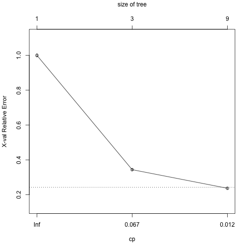

```r
plotcp(tree2.model)
```

- plot the tree

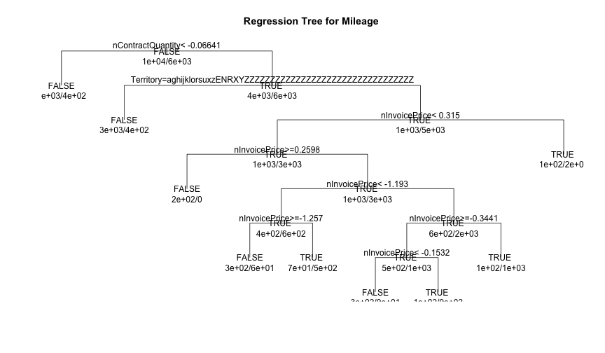

```r
plot(tree2.model, uniform=TRUE, main="Regression Tree for Mileage ")
text(tree2.model, use.n=TRUE, all=TRUE)
```

- validation

```r
tree2.valid <- dataV[c("Channel", "Territory", "nContractQuantity", "nInvoicePrice", "Discount", "isDiscount")]
tree2.valid$predP <- predict(tree2.model, newdata=tree2.valid, type="prob")[,"TRUE"]
tree2.valid$pred1 <- as.logical(predict(tree2.model, newdata=tree2.valid, type="class"))

tree2.table <- table(tree2.valid$pred1, tree2.valid$isDiscount)
tree2.table
```

```
        FALSE TRUE
  FALSE  5196  466
  TRUE    221 2262
```

- plot ROC.

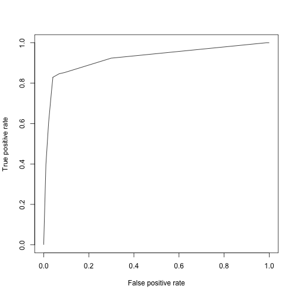

```r
require(ROCR)
tree2.pred <- prediction(tree2.valid$predP, tree2.valid$isDiscount)
# Plot ROC curve
tree2.ROC <- performance(tree2.pred, measure = "tpr", x.measure = "fpr")
plot(tree2.ROC)
```

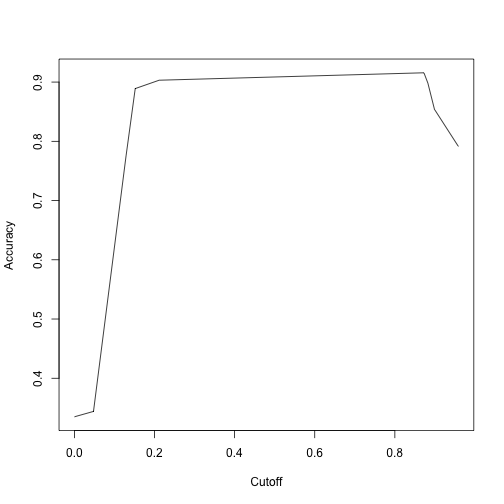

```r
# Plot precision/recall curve
#tree2.precision <- performance(tree2.pred, measure = "prec", x.measure = "rec")
#plot(tree2.precision)
# Plot accuracy as function of threshold
tree2.accuracy <- performance(tree2.pred, measure = "acc")
plot(tree2.accuracy)
```

# 4. Random Forest prediction of isDiscount

- Train model and summary result.

```r
library(randomForest)
forest1.model <- randomForest(as.factor(isDiscount) ~ nContractQuantity  + nInvoicePrice + Channel, data=dataT)
summary(forest1.model)
```

```
                Length Class  Mode
call                3  -none- call
type                1  -none- character
predicted       19002  factor numeric
err.rate         1500  -none- numeric
confusion           6  -none- numeric
votes           38004  matrix numeric
oob.times       19002  -none- numeric
classes             2  -none- character
importance          3  -none- numeric
importanceSD        0  -none- NULL
localImportance     0  -none- NULL
proximity           0  -none- NULL
ntree               1  -none- numeric
mtry                1  -none- numeric
forest             14  -none- list
y               19002  factor numeric
test                0  -none- NULL
inbag               0  -none- NULL
terms               3  terms  call
```

```r
print(forest1.model) # view results
```

```
Call:
 randomForest(formula = as.factor(isDiscount) ~ nContractQuantity +      nInvoicePrice + Channel, data = dataT)
               Type of random forest: classification
                     Number of trees: 500
No. of variables tried at each split: 1

        OOB estimate of  error rate: 4.6%
Confusion matrix:
      FALSE TRUE class.error
FALSE 12373  459     0.03577
TRUE    415 5755     0.06726
```

```r
importance(forest1.model) #importance of each predictor
```

```
                  MeanDecreaseGini
nContractQuantity             2976
nInvoicePrice                 1643
Channel                       1645
```

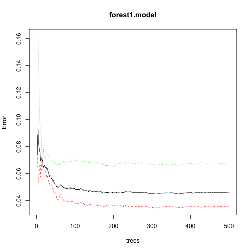

```r
plot(forest1.model)
```

- Validation

```r
forest1.valid <- dataV[c("Channel", "nContractQuantity", "nInvoicePrice", "Discount", "isDiscount")]
forest1.valid$predP <- predict(forest1.model, newdata=forest1.valid, type="prob")[,"TRUE"]
forest1.valid$pred1 <- as.logical(predict(forest1.model, newdata=forest1.valid, type="response"))

forest1.table <- table(forest1.valid$pred1, forest1.valid$isDiscount)
forest1.table
```

```
        FALSE TRUE
  FALSE  5206  203
  TRUE    211 2525
```

- Plot ROC.

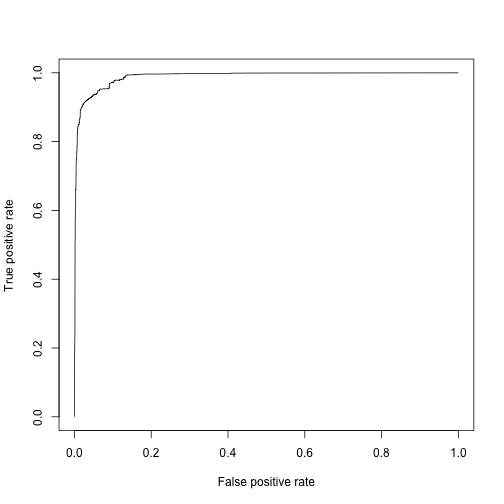

```r
require(ROCR)
forest1.pred <- prediction(forest1.valid$predP, forest1.valid$isDiscount)
# Plot ROC curve
forest1.ROC <- performance(forest1.pred, measure = "tpr", x.measure = "fpr")
plot(forest1.ROC)
```

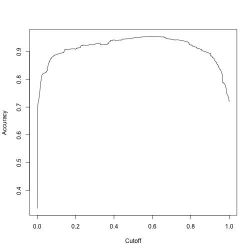

```r
# Plot precision/recall curve
#forest1.precision <- performance(forest1.pred, measure = "prec", x.measure = "rec")
#plot(forest1.precision)
# Plot accuracy as function of threshold
forest1.accuracy <- performance(forest1.pred, measure = "acc")
plot(forest1.accuracy)
```

# 5. SVM classification

- Train SVM

```r
require(e1071)

## first-time run of SVM requires optimization of parameters gamma and cost
#svm.tune <- tune.svm(as.factor(isDiscount) ~ nContractQuantity  + nInvoicePrice + Channel + Territory, data = dataT, validation.x=dataV, gamma = 2^(-1:5), cost = 10^(1:4), probability=TRUE)
#svm.model <- svm.tune$best.model

## directly use the obtained optimal parameter gamma=8, cost=10000
svm.model <- svm(as.factor(isDiscount) ~ nContractQuantity  + nInvoicePrice + Channel + Territory, data = dataT, cost = 10000, gamma = 8, probability=TRUE)
summary(svm.model)
```

```
Call:
svm(formula = as.factor(isDiscount) ~ nContractQuantity + nInvoicePrice + Channel + Territory, data = dataT, cost = 10000, gamma = 8,
    probability = TRUE)


Parameters:
   SVM-Type:  C-classification
 SVM-Kernel:  radial
       cost:  10000
      gamma:  8

Number of Support Vectors:  5226

 ( 3211 2015 )


Number of Classes:  2

Levels:
 FALSE TRUE
```

- Validation

```r
svm.valid <- dataV[c("Channel", "Territory", "nContractQuantity", "nInvoicePrice", "Discount", "isDiscount")]
svm.valid$pred1 <- as.logical(predict(svm.model, newdata=svm.valid))
svm.valid$predP <- attr(predict(svm.model, newdata=svm.valid, probability=TRUE), "probabilities")[,"TRUE"]

svm.table <- table(svm.valid$pred1, svm.valid$isDiscount)
svm.table
```

```
        FALSE TRUE
  FALSE  5243  219
  TRUE    174 2509
```

- Plot ROC

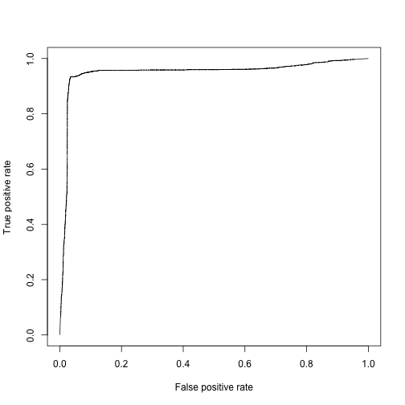

```r
require(ROCR)
svm.pred <- prediction(svm.valid$predP, svm.valid$isDiscount)
# Plot ROC curve
svm.ROC <- performance(svm.pred, measure = "tpr", x.measure = "fpr")
plot(svm.ROC)
```

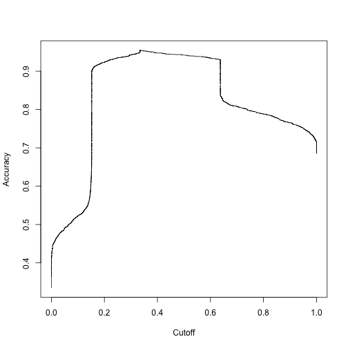

```r
# Plot precision/recall curve
#svm.precision <- performance(svm.pred, measure = "prec", x.measure = "rec")
#plot(svm.precision)
# Plot accuracy as function of threshold
svm.accuracy <- performance(svm.pred, measure = "acc")
plot(svm.accuracy)
```

- Visualize the SVM model

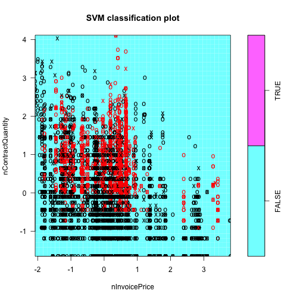

```r
plot(svm.model, data = dataV, formula = nContractQuantity ~ nInvoicePrice)
```